# Week2_classActivity

Mallikarjuna Rao Mannem

2023-09-12

## Installed packages

```r
# Load necessary packages
library(tidyverse)
library(ggthemes)
library(flextable)
library(corrr)
```

```r
# Set ggplot theme for visualizations
theme_set(ggthemes::theme_few())

# Set options for flextables
set_flextable_defaults(na_str = "NA")

# Load function for printing tables nicely
source("https://raw.githubusercontent.com/dilernia/STA323/main/Functions/make_flex.R")
```

# Importing Penguins data

```r
# Load Palmer penguins data
penguins <- readr::read_csv("https://raw.githubusercontent.com/dilernia/STA323/main/Data/penguins.csv")
```

### The five-number summary is a commonly used set of statistics, consisting of the xmin, Q1, the median, Q3, and xmax.

### Let’s look at some statistics for the flipper lengths in mm of the Palmer penguins.

```r
# Calculating descriptive statistics
quant1Stats <- penguins %>%
  dplyr::summarize(
  Minimum = min(flipper_length_mm, na.rm = TRUE),
  Q1 = quantile(flipper_length_mm, na.rm = TRUE, probs = 0.25),
  M = median(flipper_length_mm, na.rm = TRUE),
  Q3 = quantile(flipper_length_mm, na.rm = TRUE, probs = 0.75),
  Maximum = max(flipper_length_mm, na.rm = TRUE),
  Mean = mean(flipper_length_mm, na.rm = TRUE),
  R = Maximum - Minimum,
  s = sd(flipper_length_mm, na.rm = TRUE)
)

# Printing table of statistics
quant1Stats %>%
  make_flex(caption = "Quantitative summary statistics for penguin flipper lengths (mm).")
```

Table 1: Quantitative summary statistics for penguin flipper lengths (mm).

| Minimum | Q1 | M | Q3 | Maximum | Mean | R | s |
| --- | --- | --- | --- | --- | --- | --- | --- |
| 172.00 | 190.00 | 197.00 | 213.00 | 231.00 | 200.92 | 59.00 | 14.06 |

**What are the largest and smallest flippers lengths for penguins in this data set?**

The largest was 231mm and the smallest was 172mm.

**Provide and interpret the value of the sample median flipper length for the penguins.**

M = 197mm, so 50% of penguins in the data set had a flipper length 197mm or longer.

**Provide the value of the sample variance of the flipper length for the penguins.**

Since s = 14.06, the sample variance is s<sup>2</sup>= 197.6836mm^2

**Which statistic is more sensitive to outliers: the range or the interquartile-range (IQR)?**

The range is more sensitive to outliers - the IQR is more robust to outliers than the range.

### Frequencies also known as counts are useful descriptive statistics for categorical variables. The categorical variables in this data set we can calculate frequency tables for are: species, island, and sex.

```r
# Printing frequency tables
penguins %>%
  dplyr::count(species) %>%
  make_flex(caption = "Number of penguins by species.")
```

Table 2: Number of penguins by species.

| species | n |
| --- | --- |
| Adelie | 152 |
| Chinstrap | 68 |
| Gentoo | 124 |

```r
# Printing frequency tables
penguins %>%
  dplyr::count(island) %>%
  make_flex(caption = "Number of penguins by island.")
```

Table 3: Number of penguins by island.

| island | n |
| --- | --- |
| Biscoe | 168 |
| Dream | 124 |
| Torgersen | 52 |

**Which penguin species had the most observations in this data set?**

Adelie with n=152.

**Which island had the least penguins measured on it?**

Torgersen with n=52.

### Recreate the histogram and a box plot for the penguin flipper lengths

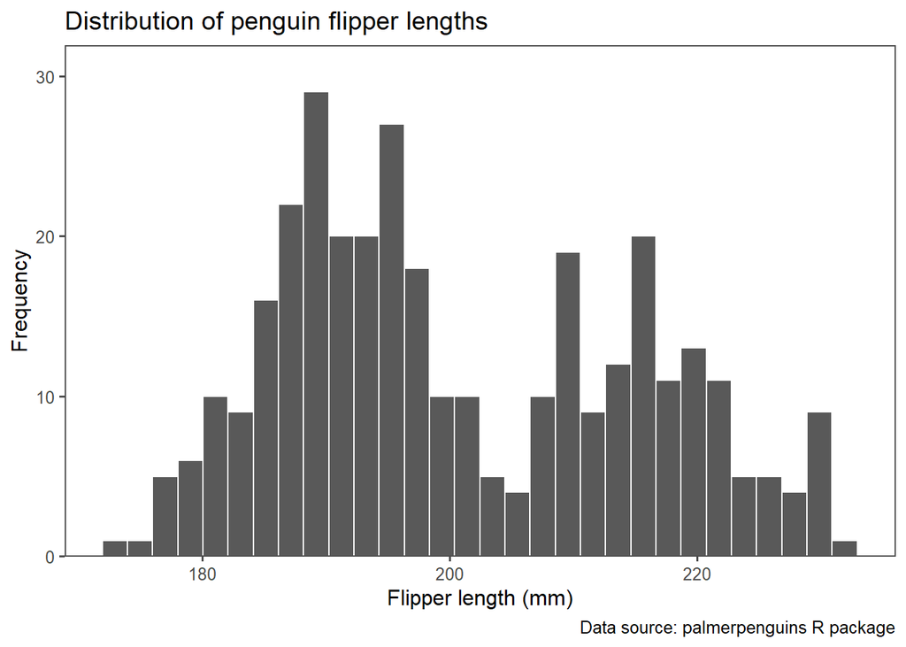

```r
# Creating a histogram
penguins %>%
  ggplot(aes(x = flipper_length_mm)) +
  geom_histogram(color = "white") +
  scale_y_continuous(expand = expansion(mult = c(0, 0.10))) +
  labs(title = "Distribution of penguin flipper lengths",
       x = "Flipper length (mm)",
       y = "Frequency",
       caption = "Data source: palmerpenguins R package")
```

### Box Plot

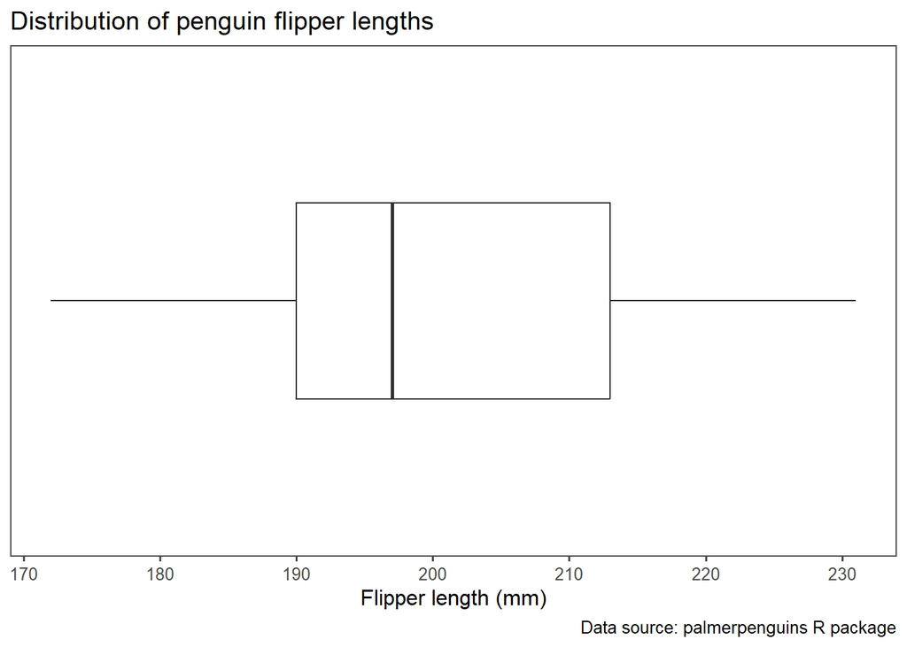

```r
# Creating a box plot
penguins %>%
  ggplot(aes(x = flipper_length_mm)) +
  geom_boxplot() +
  scale_y_discrete(breaks = NULL) +
    labs(title = "Distribution of penguin flipper lengths",
       x = "Flipper length (mm)",
       caption = "Data source: palmerpenguins R package")
```

**What can we say about the penguin flipper lengths based on the histogram?**

[output not shown]

**What can we say about the penguin flipper lengths based on the box plot? Are there any outliers present?**

```
Box plot cannot say about the modal type.
```

### Modifying the code for the previous histogram, recreate the histogram below for the body mass variable.

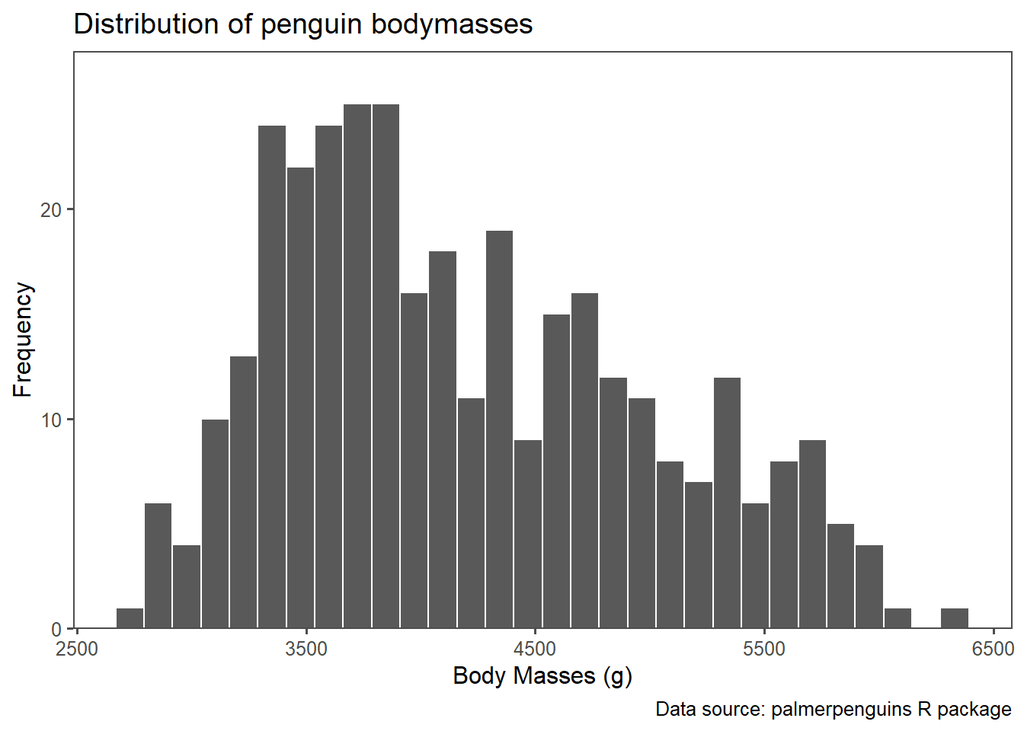

```r
# Creating a histogram
penguins %>%
  ggplot(aes(x = body_mass_g)) +
  geom_histogram(color = "white") +
  scale_y_continuous(expand = expansion(mult = c(0, 0.10))) +
  labs(title = "Distribution of penguin bodymasses",
       x = "Body Masses (g)",
       y = "Frequency",
       caption = "Data source: palmerpenguins R package")
```

### Recreate the bar chart displaying the number of penguins of each species below.

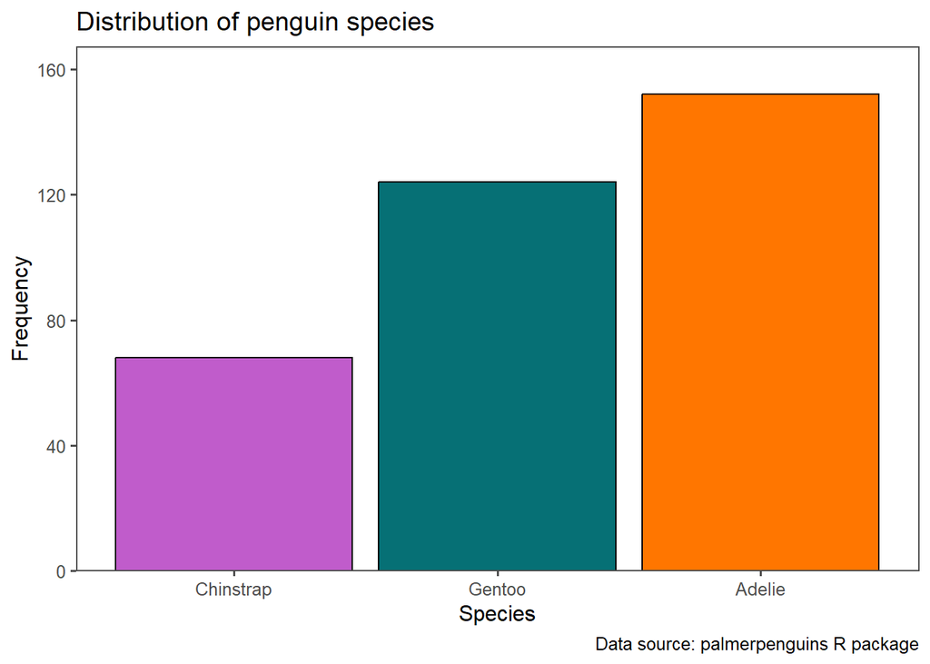

```r
# Creating a bar chart

penguins %>% dplyr::count(species, .drop = FALSE) %>%
  mutate(species = fct_reorder(species, n)) %>%
  ggplot(aes(x = species, y = n,
             fill = species)) +
  geom_col(color = "black") +
  scale_fill_manual(values = c("#c05ccb", "#067075", "#ff7600")) +
    scale_y_continuous(expand = expansion(mult = c(0, 0.10))) +
    labs(title = "Distribution of penguin species",
       x = "Species",
       y = "Frequency",
       caption = "Data source: palmerpenguins R package") +
  theme(legend.position = "none")
```

**What can we say about the penguin species based on the bar chart?**

Linear and Unimodal.

**Modifying the code for the previous bar chart, recreate the bar chart below for the island variable. Hint: the hex codes for the color-blind friendly colors in the bar chart are c(“#1F77B4”, “#2CA02C”, “#D62728”).**

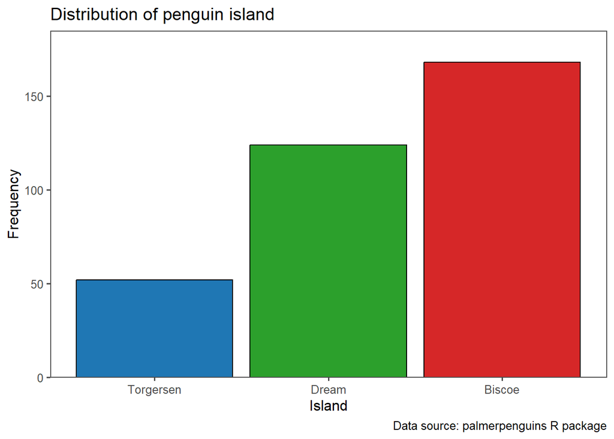

```r
# Creating a bar chart

penguins %>% dplyr::count(island, .drop = FALSE) %>%
  mutate(island = fct_reorder(island, n)) %>%
  ggplot(aes(x = island, y = n,
             fill = island)) +
  geom_col(color = "black") +
  scale_fill_manual(values = c("#1F77B4", "#2CA02C", "#D62728")) +
    scale_y_continuous(expand = expansion(mult = c(0, 0.10))) +
    labs(title = "Distribution of penguin island",
       x = "Island",
       y = "Frequency",
       caption = "Data source: palmerpenguins R package") +
  theme(legend.position = "none")
```

## Bivariate descriptive statistics

### Let’s look at the correlations for the penguins data:

```r
# Calculating correlations
corTable <- penguins %>%
  corrr::correlate(diagonal = 1)
```

```
## Non-numeric variables removed from input: `species`, `island`, and `sex`
## Correlation computed with
## • Method: 'pearson'
## • Missing treated using: 'pairwise.complete.obs'
```

```r
# Printing table of correlations
corTable %>%
  make_flex(caption = "Table of pairwise correlations.")
```

Table 4: Table of pairwise correlations.

| term | bill_length_mm | bill_depth_mm | flipper_length_mm | body_mass_g | year |
| --- | --- | --- | --- | --- | --- |
| bill_length_mm | 1.00 | -0.24 | 0.66 | 0.60 | 0.05 |
| bill_depth_mm | -0.24 | 1.00 | -0.58 | -0.47 | -0.06 |
| flipper_length_mm | 0.66 | -0.58 | 1.00 | 0.87 | 0.17 |
| body_mass_g | 0.60 | -0.47 | 0.87 | 1.00 | 0.04 |
| year | 0.05 | -0.06 | 0.17 | 0.04 | 1.00 |

**Which variables have the strongest correlation?**

flipper_length_mm and body_mass_g have the strongest correlation with r = 0.87.

**Which variables have the weakest correlation?**

body_mass_g and year has weakest correlation with r = 0.04.

### Recreate the table of statistics for the flipper lengths of the penguins stratified by species below.

```r
# Calculating descriptive statistics
quant2Stats <- penguins %>%
  group_by(species) %>%
  summarize(
  Minimum = min(flipper_length_mm, na.rm = TRUE),
  Q1 = quantile(flipper_length_mm, na.rm = TRUE, probs = 0.25),
  M = median(flipper_length_mm, na.rm = TRUE),
  Q3 = quantile(flipper_length_mm, na.rm = TRUE, probs = 0.75),
  Maximum = max(flipper_length_mm, na.rm = TRUE),
  Mean = mean(flipper_length_mm, na.rm = TRUE),
  R = Maximum - Minimum,
  s = sd(flipper_length_mm, na.rm = TRUE),
  n = n()
)

# Printing table of statistics
quant2Stats %>%
  make_flex(caption = "Summary statistics for penguin flipper lengths by species.")
```

Table 5: Summary statistics for penguin flipper lengths by species.

| species | Minimum | Q1 | M | Q3 | Maximum | Mean | R | s | n |
| --- | --- | --- | --- | --- | --- | --- | --- | --- | --- |
| Adelie | 172.00 | 186.00 | 190.00 | 195.00 | 210.00 | 189.95 | 38.00 | 6.54 | 152 |
| Chinstrap | 178.00 | 191.00 | 196.00 | 201.00 | 212.00 | 195.82 | 34.00 | 7.13 | 68 |
| Gentoo | 203.00 | 212.00 | 216.00 | 221.00 | 231.00 | 217.19 | 28.00 | 6.48 | 124 |

**Which penguin species typically had the largest flipper lengths?**

**Which penguin species had the most variability in their flipper lengths?**

### Frequency Table

```r
# Creating frequency table
speciesIslandCounts <- penguins %>%
  dplyr::count(species, island)

# Printing frequency table
speciesIslandCounts %>%
  make_flex(caption = "Number of penguins by island and species.")
```

Table 6: Number of penguins by island and species.

| species | island | n |
| --- | --- | --- |
| Adelie | Biscoe | 44 |
| Adelie | Dream | 56 |
| Adelie | Torgersen | 52 |
| Chinstrap | Dream | 68 |
| Gentoo | Biscoe | 124 |

### Bivariate visualizations

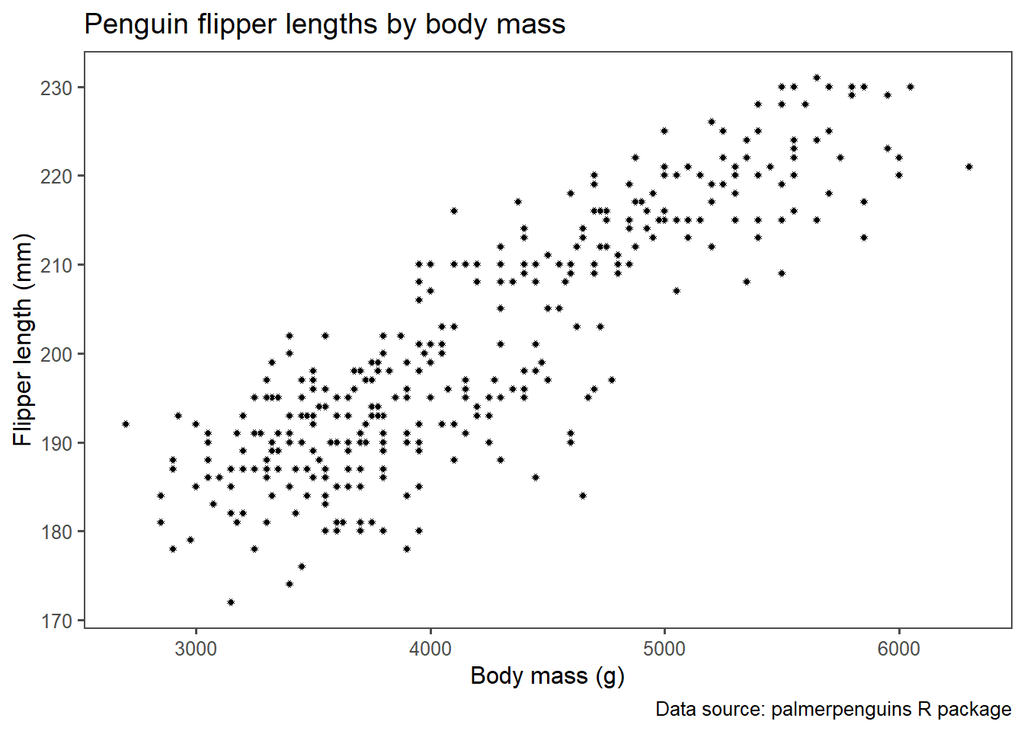

```r
# Creating a scatter plot
penguins %>%
  ggplot(aes(x = body_mass_g, y = flipper_length_mm)) +
  geom_point(pch = 21, color = "white", fill = "black") +
    labs(title = "Penguin flipper lengths by body mass",
       x = "Body mass (g)",
       y = "Flipper length (mm)",
       caption = "Data source: palmerpenguins R package")
```

### We can also add a straight line of best fit to scatter plots as well.

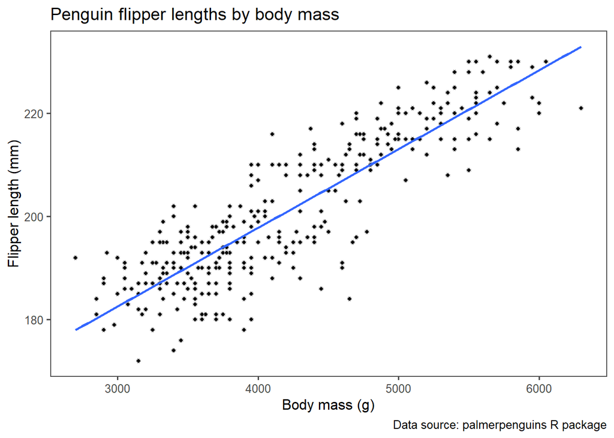

```r
# Creating a scatter plot with a line of best fit
penguins %>%
  ggplot(aes(x = body_mass_g, y = flipper_length_mm)) +
  geom_point(pch = 21, color = "white", fill = "black") +
  geom_smooth(method = 'lm', se = FALSE) +
      labs(title = "Penguin flipper lengths by body mass",
       x = "Body mass (g)",
       y = "Flipper length (mm)",
       caption = "Data source: palmerpenguins R package")
```

### For one quantitative and one categorical variable, side-by-side box plots are a useful visualization. We can use a side-by-side boxplot to explore the penguin flipper lengths by species as below.

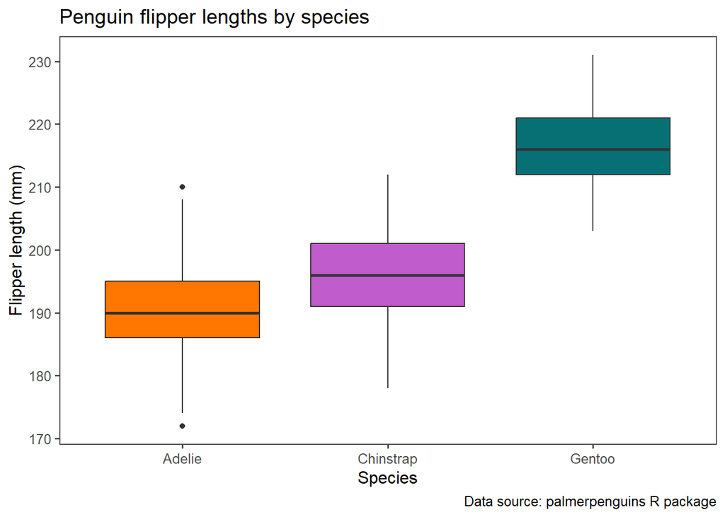

```r
# Creating side-by-side box plots
penguins %>%
  ggplot(aes(x = species, y = flipper_length_mm, fill = species)) +
  geom_boxplot() +
  scale_fill_manual(values = c("#ff7600", "#c05ccb", "#067075")) +
        labs(title = "Penguin flipper lengths by species",
       x = "Species",
       y = "Flipper length (mm)",
       caption = "Data source: palmerpenguins R package") +
  theme(legend.position = "none")
```

**What do we observe based on the side-by-side box plots?**

All the species have similar variability and Adelie has minimum flipper length and Gentoo has maximum flipper length. Adelie Species has outliers but not too far away.

### Modifying the previously provided code, recreate the side-by-side box plots below.

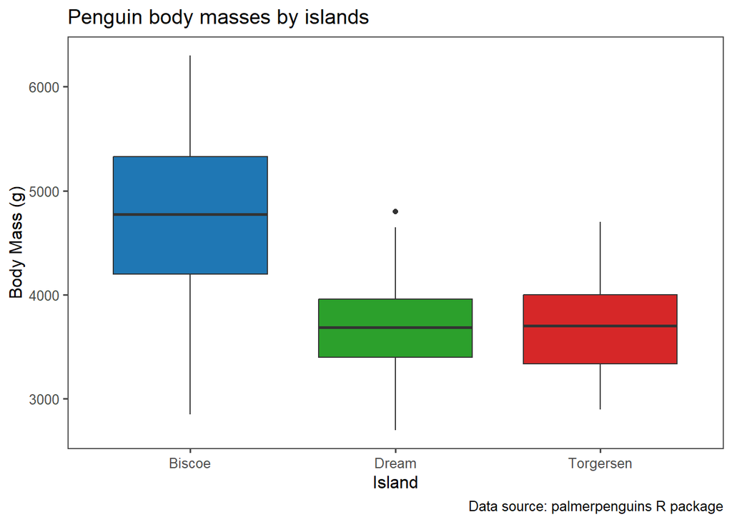

```r
# Creating side-by-side box plots
penguins %>%
  ggplot(aes(x = island, y = body_mass_g, fill = island)) +
  geom_boxplot() +
  scale_fill_manual(values = c("#1F77B4", "#2CA02C", "#D62728")) +
        labs(title = "Penguin body masses by islands",
       x = "Island",
       y = "Body Mass (g)",
       caption = "Data source: palmerpenguins R package") +
  theme(legend.position = "none")
```

### Lastly, for two categorical variables, a clustered bar chart or dumbbell chart are the more commonly used visualizations.

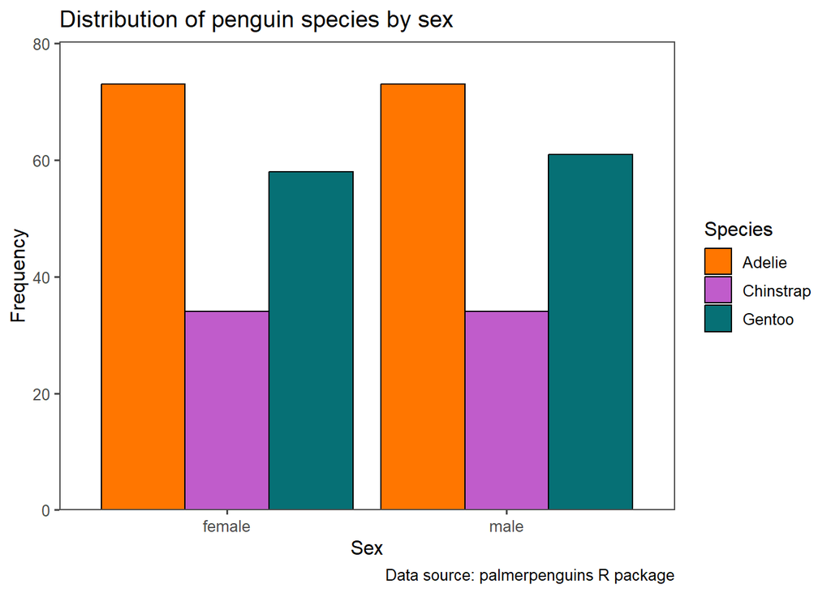

```r
# Creating a clustered bar chart
penguins %>% dplyr::count(species, sex, .drop = FALSE) %>%
    dplyr::filter(!is.na(species), !is.na(sex)) %>%
  mutate(sex = fct_reorder(sex, n)) %>%
  ggplot(aes(x = sex, y = n,
             fill = species)) +
  geom_col(position="dodge", color = "black") +
  scale_fill_manual(values = c("#ff7600", "#c05ccb", "#067075")) +
    scale_y_continuous(expand = expansion(mult = c(0, 0.10))) +
    labs(title = "Distribution of penguin species by sex",
       x = "Sex",
       y = "Frequency",
       caption = "Data source: palmerpenguins R package",
       fill = "Species")
```

### Dumbbell Chart

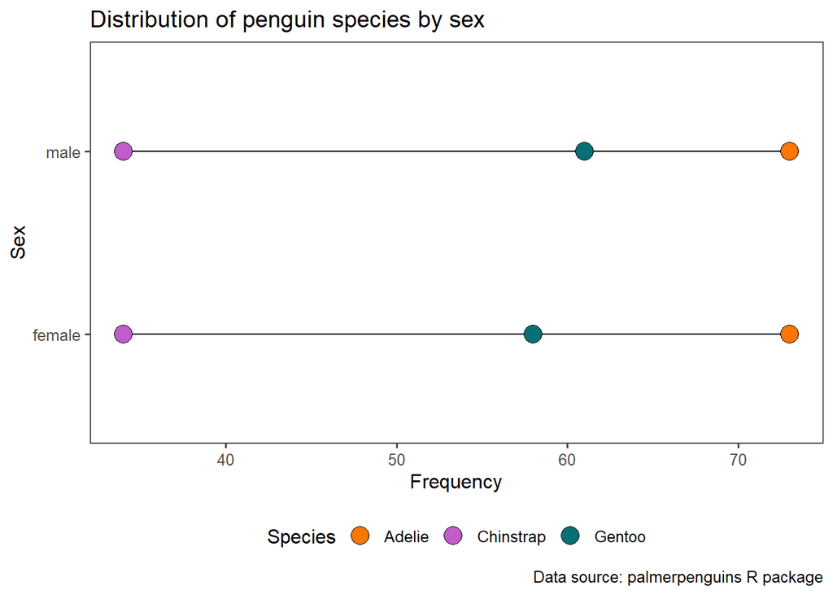

```r
# Creating dumbbell chart
penguins %>% dplyr::count(species, sex, .drop = FALSE) %>%
  dplyr::filter(!is.na(species), !is.na(sex)) %>%
  dplyr::mutate(species_sex = str_c(species, "_", sex)) %>%
  ggplot(aes(x = n, y = sex,
             color = species, fill = species)) +
  geom_line(aes(group = sex), color = "black") +
    geom_point(pch = 21, color = "black", size = 5) +
  scale_fill_manual(values = c("#ff7600", "#c05ccb", "#067075")) +
      labs(title = "Distribution of penguin species by sex",
           x = "Frequency",
           y = "Sex",
           caption = "Data source: palmerpenguins R package",
       fill = "Species") +
  theme(legend.position = "bottom")
```

**What can we say about the penguin sex and species based on the clustered bar chart and dumbbell chart?**

Male Gentoo Species are more in number than female Gentoo Species and the rest of species are same in number with respect to sex.

## Multivariate analyses

Descriptive statistics could also be obtained jointly for three or more variables, although this is less commonly done. For example, we could obtain counts for the cross-section of the species, island, and sex variables.

```r
# Creating frequency table
speciesIslandSexCounts <- penguins %>%
  dplyr::count(species, island, sex, .drop = FALSE)

# Printing frequency table
speciesIslandSexCounts %>%
  make_flex(caption = "Number of penguins by island, species, and sex.")
```

Table 7: Number of penguins by island, species, and sex.

| species | island | sex | n |
| --- | --- | --- | --- |
| Adelie | Biscoe | female | 22 |
| Adelie | Biscoe | male | 22 |
| Adelie | Dream | female | 27 |
| Adelie | Dream | male | 28 |
| Adelie | Dream | NA | 1 |
| Adelie | Torgersen | female | 24 |
| Adelie | Torgersen | male | 23 |
| Adelie | Torgersen | NA | 5 |
| Chinstrap | Dream | female | 34 |
| Chinstrap | Dream | male | 34 |
| Gentoo | Biscoe | female | 58 |
| Gentoo | Biscoe | male | 61 |
| Gentoo | Biscoe | NA | 5 |

## Multivariate visualizations

If we want to jointly visualize three variables, we can use a scatter plot coloring the points based on a third variable. Let’s look at the relationship between the penguin flipper lengths and body masses while coloring the points based on the penguin species.

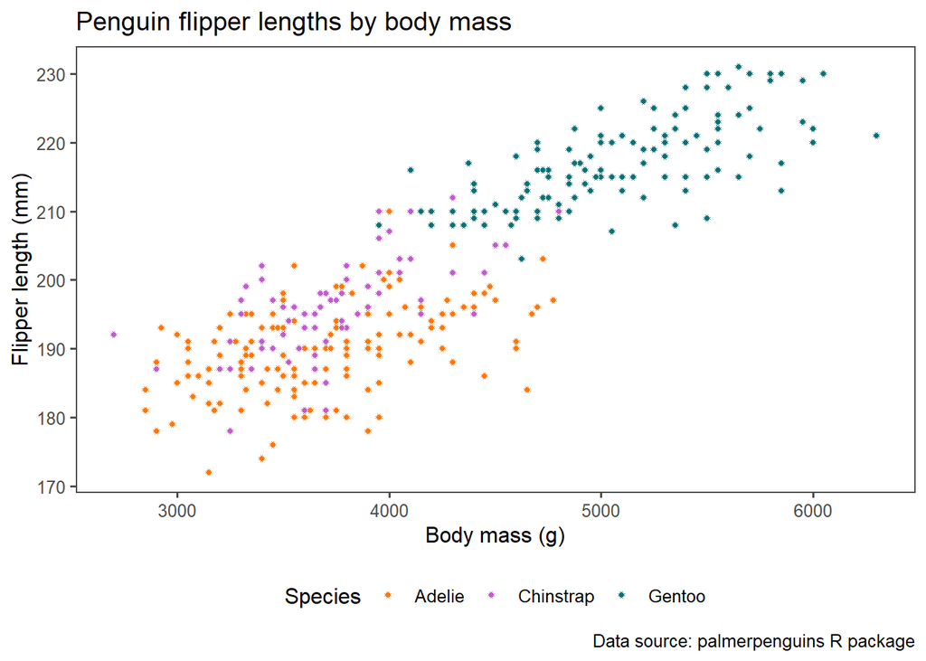

```r
# Creating a scatter plot
penguins %>%
  ggplot(aes(x = body_mass_g, y = flipper_length_mm, fill = species)) +
  geom_point(pch = 21, color = "white") +
    scale_fill_manual(values = c("#ff7600", "#c05ccb", "#067075")) +
    labs(title = "Penguin flipper lengths by body mass",
       x = "Body mass (g)",
       y = "Flipper length (mm)",
       fill = "Species",
       caption = "Data source: palmerpenguins R package") +
  theme(legend.position = "bottom")
```

**What can we say about the relationship between the penguin flipper lengths (mm) and body masses (g) for each penguin species based on the scatter plot?**

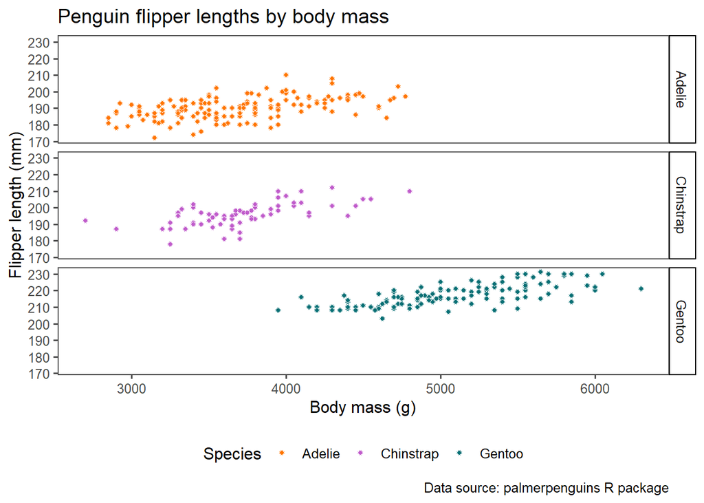

```r
# Creating a faceted scatter plot
penguins %>%
  ggplot(aes(x = body_mass_g, y = flipper_length_mm, fill = species)) +
  geom_point(pch = 21, color = "white") +
    scale_fill_manual(values = c("#ff7600", "#c05ccb", "#067075")) +
  facet_grid(species ~ .) +
    labs(title = "Penguin flipper lengths by body mass",
       x = "Body mass (g)",
       y = "Flipper length (mm)",
       fill = "Species",
       caption = "Data source: palmerpenguins R package") +
  theme(legend.position = "bottom",
        strip.background.y = element_rect(linetype = "solid", color = "black"))
```